# Problem Statement

# insights

1. Most customers contacted by the bank fall between 25 and 50 years of age.
2. Younger customers show low interest in term deposits between 18 to 25.

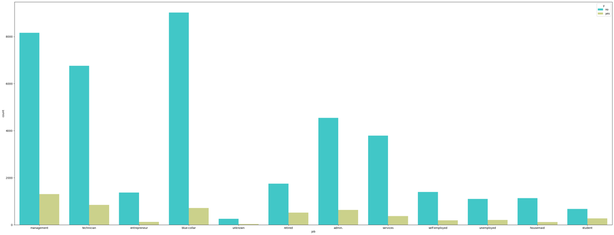

```python
# Analysing how job will play role in term deposite
plt.figure(figsize=(40,15))
sns.countplot(data=data,x='job',hue='y',palette='rainbow')
```

# Insights 1. The majority of bank customers belong to blue-collar, management, technician, and administrative job roles. 2. Blue-collar and management employees represent the largest customer segment contacted during marketing campaigns. 3. Students and unemployed customers form a very small portion of the dataset.

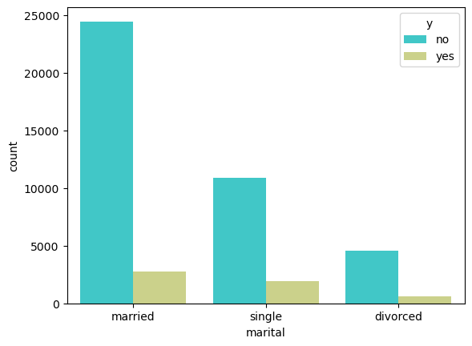

```python
# Now will analysis data of marital status by using data
sns.countplot(data=data,x='marital',hue='y',palette='rainbow')
```

# insights 1. Most customers contacted by the bank are married individuals 2. Single customers represent the second largest customer group. 3. Divorced customers constitute the smallest portion of the dataset.

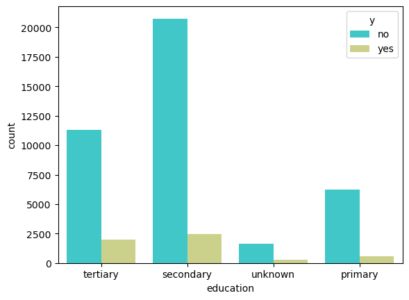

```python
# analysising education
sns.countplot(data=data,x='education',hue='y',palette='rainbow')
```

# Insights\ 1. Most customers contacted by the bank have secondary-level education. 2. Customers with primary education form a relatively smaller segment of the dataset.

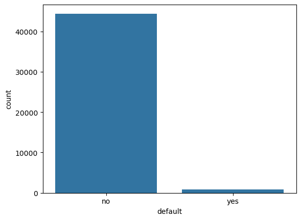

```python
# Analysing default
sns.countplot(data=data,x='default')
```

# insights 1. The majority of customers do not have any credit default history. 2. The default variable is highly imbalanced, with most customers having no credit default.

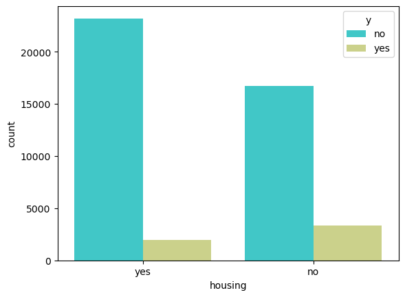

```python
# Analysing housing
sns.countplot(data=data,x='housing',hue='y',palette='rainbow')
```

# insights 1. A large position of customers have active housing loans. 2. Customers without housing loans form a smaller segment of the dataset

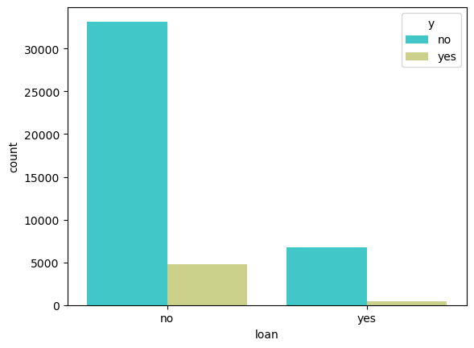

```python
# analysing loan
sns.countplot(data=data,x='loan',hue='y',palette='rainbow')
```

# Insights 1. Customers who do not have personal loans are more likely to subscribe to term deposits 2. Customers with active personal loans show very low subscription rates

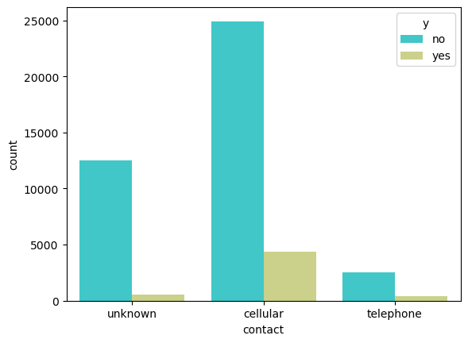

```python
# Analysing contact
sns.countplot(data=data,x='contact',hue='y',palette='rainbow')
```